### Marcela García Hernández Cinvestav-IPN 27-July-2020

[Information for New Student by Marcela](https://confluence.desy.de/x/aitZCQ)

# Important links Belle II

[Question](https://questions.belle2.org/questions/)  
[Software Belle II](https://software.belle2.org/)  
[Stash Software](https://stash.desy.de/projects/B2/repos/software/browse)  
[Jira](https://agira.desy.de/secure/Dashboard.jspa)  
[SoftwareTechnologiesTutorials](https://confluence.desy.de/display/BI/Basic+Software+Technologies+Tutorials)  
[gbasf2](https://confluence.desy.de/pages/viewpage.action?pageId=47819144)

## Installing Jupyter Notebook Belle II

[jupyternotebookBelleII](https://confluence.desy.de/display/BI/How+to+run+jupyter+notebooks+at+KEKCC)

# Working localy and installing new packages:

### Anaconda:

[Install Anaconda](https://docs.anaconda.com/anaconda/install/)

### Conda enviroment:

[New enviroment](https://docs.conda.io/projects/conda/en/latest/user-guide/tasks/manage-environments.html)

### Mini conda (KEKCC, ...)

[Install miniconda](https://conda.io/projects/conda/en/latest/user-guide/install/linux.html)

Another option is working with python enviroments

## Installling Jupyter notebook

`conda install -c conda-forge notebook`  
`pip install notebook`  
To run jupyter:  
`jupyter notebook`

# Introduction to Jupyter and Python

[Python Language Tutorial](http://nbviewer.ipython.org/github/ehmatthes/intro_programming/blob/master/notebooks/hello_world.ipynb)

#### Evaluate a cell with `Shift+Enter` (like in e.g. Mathematica notebooks)

```python
print("Hello :) !!!")
```

```
Hello :) !!!
```

# Python

In Python code blocks are done by indenting the block with spaces. There are no braces for scoping, this is soley done by code indentation.

### Basics:

```python
w=True
x=5
y=5.0
z="hola"
```

```python
type(x)
```

```
int
```

```python
lista=[w,x,y,z]
```

```python
tupla=(x,y,z,w)
```

```python
dic={"var1":x,"var2":y, "var3":z, 4.0:x+y,(1,2):w}
```

```python
for element in dic:
    print(element)
```

```
var1
var2
var3
4.0
(1, 2)
```

```python
def funtion_1():
    for element in dic:
        print("--->", element)
```

```python
class Person:
    def __init__(self, name):
        """This is the 'constructor'"""
        # Member variables are defined in the constructor

        #: The name of the person
        self.name = name

    def introduce(self):
        """Prints a sort introduction statement about the person"""
        print( "Hello, I am " + self.name + ".")

    def __str__(self):
        """This gets called when the object is passed to a print statement"""
        return self.name

    def print_name(self):
        print(self.name)

def greet(pers):
    print("Hello", pers)
```

```python
myperson = Person("Max Mustermann")
```

```python
myperson.introduce()
myperson.print_name()
greet(myperson)
```

```
Hello, I am Max Mustermann.
Max Mustermann
Hello Max Mustermann
```

```python
with open("archivo.txt", "w") as file:
    file.write("values")
```

```python
import numpy as np
```

```python
np.cos(2*np.pi)
```

```
1.0
```

```python
#help(np.cos)
```

> Help in Belle II software !

```python
import basf2 as b2
```

```python
import modularAnalysis as ma
```

```
Welcome to JupyROOT 6.18/00
```

```python
help(ma.inputMdst)
```

```
Help on function inputMdst in module modularAnalysis:

inputMdst(environmentType, filename, path, skipNEvents=0, entrySequence=None, *, parentLevel=0)
    Loads the specified ROOT (DST/mDST/muDST) file with the RootInput module.

    The correct environment (e.g. magnetic field settings) are determined from
    the specified environment type. For the possible values please see
    `inputMdstList()`

    Parameters:
        environmentType (str): type of the environment to be loaded
        filename (str): the name of the file to be loaded
        path (basf2.Path): modules are added to this path
        skipNEvents (int): N events of the input file are skipped
        entrySequence (str): The number sequences (e.g. 23:42,101) defining the entries which are processed.
        parentLevel (int): Number of generations of parent files (files used as input when creating a file) to be read
```

```python
%%cpp
cout << "This is a C++ cell" << endl;
```

```
This is a C++ cell
```

# ROOT--> PyROOT

## From ROOT `.C` Macros to Python

If you are familiar with ROOT in .C macros conversion to Python is rather simple: All ROOT objects are in the ROOT module

- **Variable Assignments:** Drop the `new` and variable type, add a `ROOT.` before the constructor. Remove the semi colon. So

  ```
  TH1D* hist = new TH1D("name", "title", 100, -5 ,5);
  ```

  and also

  ```
  TH1D hist("name", "title", 100, -5, 5);
  ```

  becomes

  ```
  hist = ROOT.TH1D("name", "title", 100, -5, 5)
  ```

- **Member dereference:** Replace all `->` with `.`

The most important difference however is that python has a stricter memory management than ROOT expects: **Make sure you keep the objects you want to draw, if they go out of scope python deletes them and ROOT cannot plot them**

[figure not shown]

# PyROOT tutorials

https://root.cern/doc/master/group__tutorial__pyroot.html

```python
mu, sigma = 0, 0.1 # mean and standard deviation
s = np.random.normal(mu, sigma, 1000)
```

```python
import ROOT
```

```python
h1 = ROOT.TH1D("h1", "h1", 100, -1.0, 1.0)
```

```python
for element in s:
    h1.Fill(element)
```

```python
def createCanvas(title):
    c = ROOT.TCanvas("c", title, 800, 800)
    return c
```

```python
c1=createCanvas("My first histogram")
c1.cd()
h1.Draw()
```

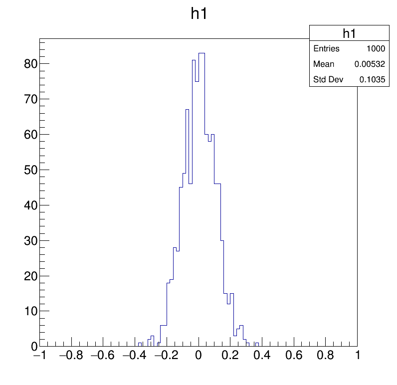

```python
c1.Draw()
```

# matplotlib

[Plotting with Python matplotlib](http://nbviewer.ipython.org/github/jrjohansson/scientific-python-lectures/blob/master/Lecture-4-Matplotlib.ipynb)

```python
import matplotlib.pyplot as plt
%matplotlib inline
```

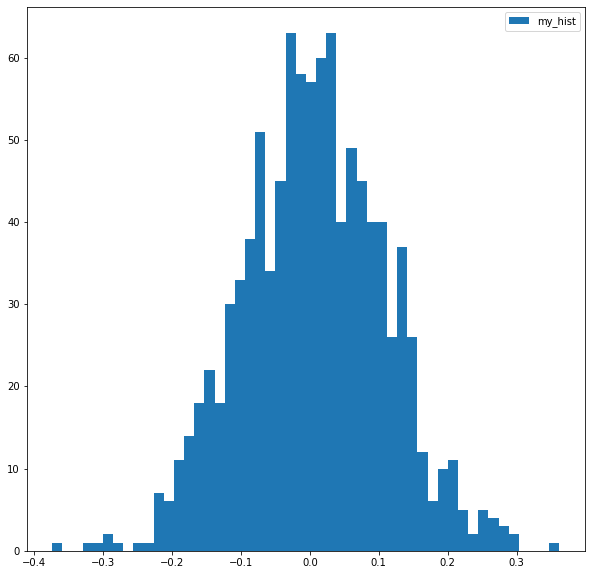

```python
plt.figure(figsize=(10,10))
plt.hist(s, bins=50,label="my_hist")
plt.legend()
```

```python
import root_pandas
```

```python
file="./tau_muon_ntuples.root"
```

```python
df_signal = root_pandas.read_root(file,key="treevpho")
```

Another option uproot  
https://github.com/scikit-hep/uproot

```python
import uproot
```

```python
signal2 = uproot.open(file)
```

### Going back to Pandas...

```python
df_signal.describe() #head() values coulums
```

|  | __experiment__ | __run__ | __event__ | __candidate__ | __ncandidates__ | __weight__ | thrust | missingEnergyOfEventCMS | missingMomentumOfEvent | missingMomentumOfEvent_theta | ... | tau_1_pi_y_uncertainty | tau_1_pi_z_uncertainty | tau_1_pi_dphi | tau_1_pi_dcosTheta | tau_1_pi_prodVertexX | tau_1_pi_prodVertexY | tau_1_pi_prodVertexZ | tau_1_pi_prodVertexXErr | tau_1_pi_prodVertexYErr | tau_1_pi_prodVertexZErr |
| --- | --- | --- | --- | --- | --- | --- | --- | --- | --- | --- | --- | --- | --- | --- | --- | --- | --- | --- | --- | --- | --- |
| count | 105574.0 | 105574.0 | 105574.000000 | 105574.000000 | 105574.000000 | 105574.0 | 105574.000000 | 105574.000000 | 105574.000000 | 105574.000000 | ... | 1.055740e+05 | 105574.000000 | 105574.000000 | 105574.000000 | 105574.0 | 105574.0 | 105574.0 | 105574.0 | 105574.0 | 105574.0 |
| mean | 1003.0 | 0.0 | 2505.363830 | 0.113787 | 1.227575 | 1.0 | 0.939655 | 2.801830 | 2.699948 | 1.331862 | ... | 3.179689e-03 | 0.008743 | -0.088422 | 0.056525 | -999.0 | -999.0 | -999.0 | -999.0 | -999.0 | -999.0 |
| std | 0.0 | 0.0 | 1441.900473 | 0.412915 | 0.620290 | 0.0 | 0.025131 | 1.460836 | 1.506168 | 0.655581 | ... | 1.980393e-02 | 0.077668 | 1.812575 | 0.858508 | 0.0 | 0.0 | 0.0 | 0.0 | 0.0 | 0.0 |
| min | 1003.0 | 0.0 | 1.000000 | 0.000000 | 1.000000 | 1.0 | 0.687150 | -98.972160 | 0.011352 | 0.010040 | ... | 2.013501e-07 | 0.000394 | -3.141582 | -1.000000 | -999.0 | -999.0 | -999.0 | -999.0 | -999.0 | -999.0 |
| 25% | 1003.0 | 0.0 | 1256.000000 | 0.000000 | 1.000000 | 1.0 | 0.928379 | 1.698873 | 1.536484 | 0.814398 | ... | 6.290490e-04 | 0.001502 | -1.666168 | -0.936808 | -999.0 | -999.0 | -999.0 | -999.0 | -999.0 | -999.0 |
| 50% | 1003.0 | 0.0 | 2506.000000 | 0.000000 | 1.000000 | 1.0 | 0.944568 | 2.852729 | 2.641456 | 1.268063 | ... | 1.128538e-03 | 0.002172 | -0.173528 | 0.234949 | -999.0 | -999.0 | -999.0 | -999.0 | -999.0 | -999.0 |
| 75% | 1003.0 | 0.0 | 3751.000000 | 0.000000 | 1.000000 | 1.0 | 0.956606 | 3.936871 | 3.747027 | 1.805447 | ... | 1.939884e-03 | 0.004137 | 1.479602 | 0.963322 | -999.0 | -999.0 | -999.0 | -999.0 | -999.0 | -999.0 |
| max | 1003.0 | 0.0 | 5000.000000 | 7.000000 | 8.000000 | 1.0 | 0.999627 | 6.067354 | 130.075798 | 3.140176 | ... | 1.606472e+00 | 12.681633 | 3.141483 | 1.000000 | -999.0 | -999.0 | -999.0 | -999.0 | -999.0 | -999.0 |

8 rows × 376 columns

```python
df_signal.sort_values(by="thrust").head()
```

|  | __experiment__ | __run__ | __event__ | __candidate__ | __ncandidates__ | __weight__ | thrust | missingEnergyOfEventCMS | missingMomentumOfEvent | missingMomentumOfEvent_theta | ... | tau_1_pi_y_uncertainty | tau_1_pi_z_uncertainty | tau_1_pi_dphi | tau_1_pi_dcosTheta | tau_1_pi_prodVertexX | tau_1_pi_prodVertexY | tau_1_pi_prodVertexZ | tau_1_pi_prodVertexXErr | tau_1_pi_prodVertexYErr | tau_1_pi_prodVertexZErr |
| --- | --- | --- | --- | --- | --- | --- | --- | --- | --- | --- | --- | --- | --- | --- | --- | --- | --- | --- | --- | --- | --- |
| 77807 | 1003 | 0 | 2579 | 0 | 1 | 1.0 | 0.687150 | 3.027152 | 3.575326 | 0.590108 | ... | 0.000979 | 0.002316 | 0.357272 | -0.954584 | -999.0 | -999.0 | -999.0 | -999.0 | -999.0 | -999.0 |
| 66801 | 1003 | 0 | 1593 | 0 | 1 | 1.0 | 0.695020 | 2.813056 | 3.034088 | 1.159578 | ... | 0.012327 | 0.015210 | 1.610821 | 0.942887 | -999.0 | -999.0 | -999.0 | -999.0 | -999.0 | -999.0 |
| 66791 | 1003 | 0 | 1575 | 0 | 1 | 1.0 | 0.695469 | 3.848182 | 3.909879 | 1.466864 | ... | 0.001228 | 0.002873 | 0.469753 | 0.963112 | -999.0 | -999.0 | -999.0 | -999.0 | -999.0 | -999.0 |
| 21128 | 1003 | 0 | 201 | 0 | 1 | 1.0 | 0.697973 | 3.332684 | 4.210262 | 0.462916 | ... | 0.001339 | 0.001897 | 1.956125 | -0.955385 | -999.0 | -999.0 | -999.0 | -999.0 | -999.0 | -999.0 |
| 13328 | 1003 | 0 | 391 | 0 | 1 | 1.0 | 0.704517 | 2.414006 | 2.366453 | 1.308098 | ... | 0.051149 | 0.009809 | -0.562268 | -0.839878 | -999.0 | -999.0 | -999.0 | -999.0 | -999.0 | -999.0 |

5 rows × 376 columns

```
array([[<matplotlib.axes._subplots.AxesSubplot object at 0x7fd598885be0>]],
      dtype=object)
```

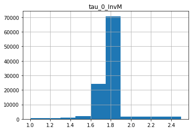

```python
df_signal.hist("tau_0_InvM")
```

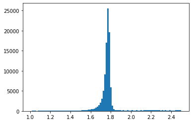

```python
h = plt.hist(df_signal["tau_0_InvM"], bins=100)
```

```python
subset = df_signal[['thrust', 'tau_0_InvM']]
subset.columns
```

```
Index(['thrust', 'tau_0_InvM'], dtype='object')
```

```python
#subset
```

```python
dic_cuts={"thrust":0.8, "tau_0_InvM":1.7}
```

```python
new_subset=subset.copy()
print(len(new_subset))
for element in dic_cuts:
    print("Cut in the variable:", element)
    cut=dic_cuts[element]
    print("The cut is:", cut)
    new_subset=new_subset[new_subset[element] > cut]
    print("After this cut the len is:",len(new_subset))
print(len(new_subset))
```

```
105574
Cut in the variable: thrust
The cut is: 0.8
After this cut the len is: 105308
Cut in the variable: tau_0_InvM
The cut is: 1.7
After this cut the len is: 95085
95085
```

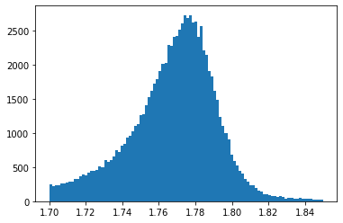

```python
h = plt.hist(new_subset["tau_0_InvM"][new_subset["tau_0_InvM"] < 1.85], bins=100)
```

# PyROOTFIT

Another option zfit  
zfit

```python
from pyroofit.models import Gauss
x = ROOT.RooRealVar('tau_0_InvM', 'M_{#tau}', 1.7, 1.82, 'GeV/c^{2}')
mean_s=(1.77, 1.71, 1.81)
sigma_s=(0.01, 0.001, 0.3)
pdf_sig = Gauss(x, mean_s, sigma=sigma_s, name="gauss")

pdf_sig.fit(new_subset)
pdf_sig.plot('fit_sig.png', legend=True)

print("Parameters:")
pdf_sig.get()
print("-------")
```

```
Parameters:
mean               ==> 1.76773+/-0.00009
sigma              ==> 0.02413+/-0.00007
-------

RooFit v3.60 -- Developed by Wouter Verkerke and David Kirkby
                Copyright (C) 2000-2013 NIKHEF, University of California & Stanford University
                All rights reserved, please read http://roofit.sourceforge.net/license.txt

[#1] INFO:Eval -- RooTreeDataStore::loadValues(data) Ignored 7998 out of range events
[#1] INFO:Minization -- RooMinimizer::optimizeConst: activating const optimization
[#1] INFO:Fitting -- RooAbsPdf::fitTo(gauss) Calculating sum-of-weights-squared correction matrix for covariance matrix
[#1] INFO:Minization -- RooMinimizer::optimizeConst: deactivating const optimization
```

```
Info in <TCanvas::Print>: png file fit_sig.png has been created
```

[figure not shown]

## Try to make a better fit

```python
#from IPython.display import Image
#Image(filename='fit_sig.png')
```

## Your best friend Google :)!

[Collection of further tutorials](https://github.com/ipython/ipython/wiki/A-gallery-of-interesting-IPython-Notebooks#introductory-tutorials)